# Todos pela Popularidade:

Como o Apoio do Presidente é Capaz de Afetar o Posicionamento dos Parlamentares Brasileiros.

Andéliton Soares

Abstract

Resumo: A pandemia do novo coronavírus estabelece forte choque exógeno. Os prejuízos são esperados e já observados, e a esquiva de culpabilidade e reivindicação de crédito são elementos importante do jogo político como um todo e da questão da pandemia em particular. O presente artigo tem como propósito analisar descritivamente os posicionamentos dos parlamentares nas duas casas legislativas brasileiras, segundo a ideologia e a proximidade ao Governo, a respeito do distanciamento social e das medidas tomadas pelo Presidente. Os resultados apontam para o fato de que a retomada da popularidade Presidencial acompanha maior apoio ao Presidente por partidos de Centro e de Direita. A Esquerda, por sua vez, possui posicionamento consistente ao enfrentamento ao Executivo Federal.

# 1 Introdução

Ainda há muito a se explorar acerca das implicações políticas do novo Coronavírus. A pandemia toca em diversas dimensões da análise política: comportamental, políticas públicas, federalismo, liderança, e, também, política legislativa. Para a saúde e gestão públicas, apresenta-se como um dos maiores desafios dos últimos tempos e, longe de limitar-se a gestores e especialistas, apresenta-se como grande problema aos pesquisadores.

Ademais, está relacionado a grandes temas sobre a capacidade da democracia de responder à crises (KAVANAGH; SINGH, 2020), as implicações geradas pela delimitação conceitual acerca dos óbitos em pesquisas comparadas (KARANIKOLOS; MONITOR, 2020), e a existência de desafios analíticos apresentados através das diversas estruturas de processo decisório, exposição midiática e organização de sistemas de saúde (BAL et al., 2020). Relata-se a especificidade da condução de políticas de saúde em relação às demais áreas de políticas públicas, sendo até mesmo defendida a tese da necessidade de um campo específico dentro da Ciência Política para o seu debate (MORONE; JACOBS, 2005). Junta-se a isso o fato de ser área extremamente sensível a parâmetros de justiça e igualdade, produzindo complexo emaranhado de identidades através do trato com doenças e assistência (CARPENTER, 2012).

No que diz respeito ao enfoque político, é possível observar uma grande preocupação com dimensões de enfrentamento da crise. Analisa-se o quão capazes de produzir resultados são as ações tomadas, tendo por pano de fundo os diferentes regimes políticos, formas de estado, poderes estatais, e parâmetros de avaliação de políticas públicas (GREER et al., 2020).

Porém, o enfoque político do fenômeno, como será defendido, não só torna possível maior compreensão das medidas tomadas e de seus efeitos, contribuindo para entendimentos de maior escala, senão que lança luz a uma importante dimensão do problema - a administração de prejuízos. Mais especificamente, como os problemas gerados pela pandemia podem inaugurar um importante cenário de reivindicação de crédito e de esquiva de responsabilidade. O choque existente entre a Presidência da República e governos estaduais já é relatado como embate de responsabilidades (MELO, 2020).

O presente artigo argumenta que a pandemia é um desafio político: é fonte de inevitáveis perdas, fazendo forças políticas não só se organizarem para o seu combate, mas, igualmente, para a administração do prejuízo político gerado. A literatura demonstra como pandemias anteriores concentram extrema sensibilidade através do caos e da crise gerados. A realidade é desastrosa e repleta de viés negativo, independente dos passos e da agilidade da ação governamental (FLINDERS, 2020). Tomando o enfoque da tendência ao maior impacto de perdas gerado pela maior sensibilidade a prejuízos do que ganhos (WEAVER, 1986), o produto acaba sendo a abertura para “jogos de culpa” que cria diferentes cenários de “esquiva de culpabilidade” (HOOD, 2010).

A pandemia, por outro lado, pode ser vista como choque exógeno, tendo a capacidade de criar oportunidades como fator unificador através do conceito de “Todos pela Pátria”, rally-‘round-the-flag[^1], como ocorre no caso dinamarquês e britânico (BAEKGAARD et al., 2020; FLINDERS, 2020). Nesse sentido, teria um efeito moderador nas preferências políticas de elites e massa. Na massa, também, o medo da morte pode gerar incentivos para posturas críticas às soluções miraculosas e não científicas para o problema, projetando a população igualmente para um caminho de moderação (Pereira et. al 2020). Por outro lado, pode ser também uma ferramenta para o aprofundamento de clivagens e da polarização política, principalmente em países governados por políticos populistas que adotam uma postura negacionista (MEYER, 2020). O Brasil, no caso, é um dos países (cinco no mundo) com uma liderança política que menospreza e reduz os impactos da pandemia, conforme aponta Meyer. Ressalta-se a importante comoção gerada por medidas contrárias ao distanciamento social por parte do Poder Executivo Federal, acompanhada de queda de popularidade nos momentos iniciais da pandemia. Após alguns meses, a popularidade do Presidente da República volta a crescer em um cenário agravante da pandemia do novo Coronavírus ao redor do mundo, existindo flexibilização do distanciamento social em diversas partes do Brasil. Bolsonaro se portou porta-voz da necessidade de flexibilização das restrições impostas à circulação de pessoas, defendendo a necessidade de abrir a economia. Fez questão de contrapor economia e pandemia, alertando para os problemas gerados no tratamento da segunda para a primeira.

Neste artigo, contribuímos com o debate através de uma análise das posições em relação ao enfretamento da pandemia adotadas pelas duas casas do Poder Legislativo brasileiro, matizado pela ideologia dos partidos e sua proximidade com o governo. Colocamos algumas questões que iremos responder com dados dos discursos parlamentares proferidos em ambas as casas. Dessa forma, busca-se saber o posicionamento dos parlamentares com relação às ações e posturas do Governo Federal, e ao distanciamento social.

Para conduzir o presente trabalho, serão considerados os discursos proferidos pelos parlamentares das duas Casas legislativas brasileiras, de março até o fim de agosto de 2020. Os seus discursos serão avaliados de acordo com as críticas e elogios feitos ao Poder Executivo Federal, tendo por unidade de análise os partidos, contrastados por sua ideologia e participação no governo. Junta-se a isso o interesse em saber como os partidos se comportaram em relação ao distanciamento social, fortemente recomendado por autoridades internacionais e adotado por diversos países, e às ações de gasto público através da transferência de recursos a cidadãos em situação de vulnerabilidade.

Por fim, observaremos o quanto o Poder Legislativo, se uniu entorno do enfrentamento da pandemia. Iremos investigar se partidos de matizes ideológicas distintas se aliaram em âmbito legislativo na defesa de medidas de enfrentamento à crise gerada pela pandemia da Covid-19.

A validade teórica das correlações empíricas pode apontar para elementos acerca da gestão da crise, sendo o efeito da opinião pública entendido como variável de peso para os pronunciamentos do Parlamento. Assim, poderemos verificar o quão custoso seria defender o Presidente em momentos de queda de seu apoio popular e o quanto a oposição pode aproveitar-se da fragilidade Presidencial ou abster-se do conflito. Analisamos como governo e oposição dividem o peso da responsabilidade e/ou se aproveitam dela.

Os resultados demonstram que partidos de esquerda são críticas de forma consistente no tempo às posições do governo, de ataques e críticas a pedidos de abertura de processos de impeachment. Já partidos ao centro e à direita evitam o tema e a criticar o Presidente. Com o crescimento da popularidade presidencial, esses partidos passam a se expor mais em defesa das ações do Governo Federal, demonstrando certo grau de aversão ao risco em momentos de queda do apoio popular e oportunismo em cenários de retomada de popularidade.

Além desta introdução, o presente artigo possui uma seção que visa a discutir, brevemente, a dinâmica política do enfrentamento da crise. Em seguida, há uma apresentação das hipóteses, a discussão metodológica e dos resultados.

# 2 O que há em jogo com a pandemia?

A pandemia, atrelada a já existente discussão acerca da crise da democracia (KEANE, 2020), traz importantes desafios de confiança, culpabilidade e entendimento (FLINDERS, 2020). Existem debates acerca da capacidade democrática em responder a atual crise de saúde pública (KAVANAGH; SINGH, 2020), demonstrando que em comparação com regimes autoritários as democracias responderam pior ao começo da pandemia (CEPALUNI; DORSCH; BRANYICZKI, 2020).

Tomando o enfoque sociopolítico, as medidas de distanciamento social trouxeram maior apoio a governos europeus, aumentando até mesmo o grau de satisfação com a democracia (BOL et al., 2020). Para o caso norte americano, pesquisadores apontam para o fato de que as crenças políticas podem afetar a percepção sobre os riscos existentes da pandemia (BARRIOS; HOCHBERG, 2020), dificultando, até mesmo, medidas de enfrentamento ao vírus (PAINTER; QIU, 2020). Já para o caso brasileiro, um estudo demonstra como o medo pode, inclusive, unir grupos ideologicamente afastados (PEREIRA; MEDEIROS; BERTHOLINI, 2020).

A pandemia gera enorme insegurança e instabilidade em seus momentos iniciais. As medidas de combate ao vírus baseiam-se no distanciamento social, com possíveis períodos de “lockdown”, o fechamento obrigatório de estabelecimentos públicos e a vedação de atividades que promovam aglomeração. As medidas de enfrentamento são importante termômetro para a opinião pública, possivelmente levando a maior ou menor adesão às práticas recomendadas, como higienização contínua das mãos, distanciamento social e o uso de máscaras. Gestores passam a ser responsabilizados por suas ações e, no Brasil, a disputa entre Governo Federal de um lado, e governos estaduais e municipais de outro acirrou o conflito político nacional, impossibilitando qualquer efeito de união em torno de uma causa comum – não houve uma dinâmica de “rally ‘round the flag”. Muito ao contrário: Bolsonaro, como fazem populistas, apostou no acirramento da polarização, defendendo posições controversas, muitas delas não apoiadas por evidências empíricas.

Do outro lado da moeda, países com muita desigualdade e pobres sofrem ainda mais, pois o distanciamento social é inviável para grande parte da população: os mais vulneráveis e pobres. Em estados federados, há a extrema pressão existente advinda da queda de arrecadação dos entes políticos e a recessão econômica potencial. Aqueles no comando do Poder Executivo têm que lidar com escolhas de distanciamento, que impactam o gasto público e a arrecadação de tributos, e de flexibilização/encerramento do distanciamento, que geram a diminuição dos impactos econômicos negativos e aumentam a probabilidade de mortes que inevitavelmente serão atribuídas a cargo de tal medida. Esse é o grande dilema posto acerca da pandemia na política nacional.

É plausível supor que o Poder Executivo sofra em maior escala[^2] , tendo como pressuposto o fato de ser linha de frente das medidas tomadas, a vitrine da gestão nacional, estadual e municipal e o principal afetado quando da recuperação econômica. Os eleitores julgarão os seus candidatos frente a um cenário de crise e que pode ser extremamente associado as ações daqueles no comando do Executivo. Já os parlamentares operam em um cenário de alto custo de entendimento e participação (NICOLAU, 2017) e possuem grande margem para evitar efeitos negativos.

Como exemplo disso, a literatura aponta que a reeleição de presidentes é sensível à situação econômica (CAMPELLO; ZUCCO, 2016; KRAMER, 1971), sendo considerada, inclusive, fator de peso para interrupção de mandados (PÉREZ-LIÑÁN, 2007). No caso brasileiro, há evidência para a desvantagem existente nas reeleições para prefeito (KLAŠNJA; TITIUNIK, 2017). No entanto, com relação aos deputados federais, trabalhos demonstram a vantagem na reeleição existente para incumbentes (MEIRELES, 2019) e a falha dos eleitores em punir condutas ilegais (BOAS; HIDALGO; MELO, 2019) e a corrupção, mitigada pelo grau de financiamento de campanha (JUCÁ; MELO; RENNÓ, 2016).

Dessa forma, pode se supor o baixo custo da crítica a medidas que flexibilizem o distanciamento e o elevado grau de retorno em posicionar-se a favor do distanciamento social, em detrimento da postura favorável da retomada econômica. Chefes do Executivo não podem se dar a esse luxo: estão impelidos a tomar decisões, de um lado ou de outro, levando em conta a opinião pública e as recomendações de especialistas.

Isso, obviamente, não implica reduzir a postura parlamentar a créditos e prejuízos, dado que é legitimo supor a preocupação e a ação em direção à “boa política”. Reduzir as ações dos deputados e senadores ao mero diálogo entre aproveitar-se de efeitos positivos e esquivar-se de efeitos negativos, seria, no mínimo, simplista. No entanto, antes de fragilizar as preferências individuais e coletivas dos parlamentares, o argumento tem por base o pressuposto teórico de que políticos são avessos ao risco (WEAVER, 1986) e que se encontram em um constante cálculo de ações com benefícios concentrados e custos dispersos (ARNOLD, 1990).

O quão endógena a ideologia é a preferência pelo distanciamento social? Ponto relevante, tomando o caso brasileiro, dado a existência de um grande embate a nível federal e estadual, demonstrando posição antagônica entre governadores e o Presidente e forte jogo de transferência de responsabilidade (MELO, 2020). Estar a favor do distanciamento significaria estar do mesmo lado de governadores, organizações internacionais, diversos países, especialistas e da opinião pública e contra o Governo Federal, especialmente nos momentos iniciais da pandemia.

O distanciamento social, em si, apesar de ter implicação econômica e à saúde pública claras, não possui posicionamento ideológico evidente. No entanto, não é de todo equivocado apontar para o fato de que, em última instância, a questão se reduz a: “O quanto vale expor vidas para salvar a economia?”. A resposta para a essa questão parece apontar para o fato de que o medo da morte aproxima ideologias distintas (PEREIRA; MEDEIROS; BERTHOLINI, 2020).

Se o medo da morte aproxima ideologias, é possível dizer que o medo da morte aproxima partidos? Seria problemático supor que partidos de oposição poderiam em algum momento apoiar medidas favoráveis ao Governo Federal no contexto do enfrentamento da pandemia, especificamente no que diz respeito ao encerramento do distanciamento social, por mais que o seu interesse fosse em direção a ações eficazes de combate em diálogo com o Governo Federal. Esse é um claro caso no qual sistemas multipartidários premiam posicionamentos fortes por parte de partidos em detrimento de posturas omissas (WEAVER, 1986).

Apoiar o distanciamento poderia ser entendido como importante ação da oposição ao Governo, não sendo surpreendente a sua constatação empírica. Não tão claro assim é se o engajamento em um conflito aberto varia de acordo com o a popularidade do Presidente. Mais especificamente: à medida que a popularidade do Presidente cresce, é possível observar o efeito previsto pela literatura de não confrontação (HETHERINGTON; NELSON, 2003)?

Com relação àqueles próximos ao Presidente, resta se perguntar qual seria o incentivo a apoiá-lo, tendo como pressuposto o radicalismo das condutas contra o distanciamento, e o altíssimo custo de estar associado a elas. Por essa razão, seria plausível supor que os apoiadores do Presidente no parlamento escolhessem evitar a sua defesa, cuidar da pandemia em outros aspectos relevantes e com baixa exposição a temas polêmicos e impopulares.

É de se imaginar, igualmente, que o apoio do Presidente tenha um custo, e que os recursos federais enviados para âmbito local possuam forte poder explicativo para o posicionamento individual e coletivo dos parlamentares (PEREIRA; MUELLER, 2002, 2003). No entanto, o presente trabalho utilizará como variável explicativa a popularidade do Presidente, tentando se aproximar a troca de recursos através dos partidos que compõem sua base de apoio – ideia operacionalizada pela ocupação de ministérios no gabinete.

# 3 Hipóteses

Com base na discussão anterior, três hipóteses centrais serão testadas. Analisaremos as posições de partidos de esquerda, centro e direita condicionadas pela popularidade presidencial e sua posição no governo. Partiremos do pressuposto que partidos de esquerda serão opositores ao atual presidente, dado seu posicionamento ideológico e a disputa colocada pelas eleições de 2018. Já partidos de direita e, principalmente, centro, tem posturas que são possivelmente menos evidentes, podendo oscilar mais em seu apoio e condicioná-lo mais diretamente a terceiros elementos – fatores intervenientes – como a popularidade do presidente. Assim: H1: À medida que a popularidade do Presidente diminui, aumentam ainda mais os ataques já realizados por partidos de esquerda. Já para partidos de direita e centro, abster-se de defender o Presidente não significa postular-se como seu opositor, senão que demonstra comportamento estratégico em relação a esquivar-se da queda de popularidade, e de posteriores responsabilidades. Além disso, uma das estratégias tomadas pelos políticos em direção à esquiva de responsabilidade é simplesmente evitar o assunto (HOOD, 2010). Dessa forma, será testada a seguinte hipótese: H2: A Direita é a única que defende o Presidente durante momentos mais sensíveis de sua popularidade, apesar de discutir menos a sua responsabilidade sobre o tema. Além disso, à medida que a popularidade presidencial cresce, esse espectro tende a discutir mais o tema e a apoiar mais intensamente o Presidente. Com relação ao Centro, existe importante hipótese a ser testada a respeito de como possui mobilidade e é sensível a popularidade presidencial. Aproveitando-se, dessa forma, de importante elemento de pressão ao Governo quando de sua baixa popularidade, e usufruindo da possibilidade de apoiar medidas que agradem a população em igual medida. Sendo, dessa forma, mais sensível a popularidade presidencial para a mudança qualitativa de seu posicionamento: H3: O Centro possui maior mobilidade qualitativa (ataque/defesa) de seus posicionamentos em função da popularidade presidencial.

# 4 Metodologia e Dados

Os discursos proferidos em plenário no período de março até o fim agosto de 2020 foram analisados para fins do presente trabalho, tendo por critério de seleção a pertinência com o tema da pandemia[^3]. Os pronunciamentos dos parlamentares foram extraídos da plataforma oficial de ambas as casas. Foram analisados mais de 4500 mil discursos que tratavam da pandemia do novo coronavírus, em ambas as casas (tabela 1 e 2). A composição da amostra dos discursos se deu através da busca por palavras-chaves sobre o tema da pandemia, havendo um processo posterior de limpeza da amostra para a eliminação de eventuais discursos duplicados[^4].

Tendo o propósito de avaliar o posicionamento dos discursos, sempre quando proferida menção expressa ao Governo Federal, em falas que tratavam da pandemia, considerou-se como ataque menções expressas ao Governo Federal seguida de avaliações negativas, e até mesmo insultos e exaltações a pedidos de impeachment. Já a defesa foi analisada em termos das contestações feitas, do apoio e do elogio expresso.

A preocupação foi avaliar os discursos de forma dicotômica segundo as categorias estipuladas. Sempre que houve menção expressa ao Governo quando do debate sobre a pandemia, seguida de avaliação positiva ou negativa, estabeleceu-se a classificação. O foco, dessa forma, não foi avaliar detalhes a respeito das proposições tratadas e das implicações das medidas defendidas para o combate a crise, mas sim o posicionamento em relação ao Governo Federal.

A ideologia dos partidos foi mensurada com base em dados de pesquisas de opinião pública no parlamento brasileiro (POWER; JR, 2009). Como a última onda de entrevistas se deu em 2017 (ZUCCO; POWER, 2019), foram feitos ajustes para categorizar partidos que trocaram de nome de legenda. Em resumo, este modelo de mensuração das ideologias partidárias se baseia em uma disposição espacial dos partidos de acordo com a própria opinião dos parlamentares. Através de suas respostas, os parlamentares recebem uma pontuação que se agrega coletivamente para compor a do partido. Dessa forma, optou-se pelo critério de composição dos espectros em três grupos (esquerda, centro e direita) com base em sua distribuição em uma “linha” de ideologia que vai dos mais à esquerda até os mais à direita.

O quadro 1 traz a distribuição dos partidos no contínuo ideológico proposto. Já o quadro 2 os reorganiza nos três campos analisados neste trabalho.

## Ideologia dos partidos

### Quadro 1: Ideologia dos partidos segundo a onda de entrevistas de 2017, do mais à esquerda ao mais à direita.

| Esquerda |  |  |  |  |  |  |  |  |  |  |  | Direita |
| --- | --- | --- | --- | --- | --- | --- | --- | --- | --- | --- | --- | --- |
|  |  |  |  |  |  |  |  | PROS | MDB |  | PSL |  |
| PSOL | PCdoB | PT | REDE | PDT | PSB | PPS | PV | SD | PSDB | PRB | PP | DEM |
|  |  |  |  |  |  |  |  | PTB | PSD |  |  |  |
|  |  |  |  |  |  |  |  | PODE | PR |  |  |  |

### Quadro 2: Recorte ideológico para o presente trabalho

| Esquerda | Centro | Direita |
| --- | --- | --- |
| PSOL; PCdoB; PT; REDE; PDT; PSB; CIDADANIA; PV | PROS;MDB;SD;PSDB;PTB;PSD;PODE;PL; AVANTE | PSL; REP.; PP; DEM; NOVO; PSC; PATRI |

**Fonte:** “Brazilian Legislative Survey” (ZUCCO; POWER, 2019) e elaboração dos autores.

Para classificar o partido como sendo da base do governo, utilizamos a estratégia classificatório de identificar a composição ministerial do gabinete (NETO, 2006). Com base nessa informação, fica claro o isolamento político do Presidente em relação aos partidos com representantes no Congresso Nacional. Conforme apontam Amorim Neto e Pimenta (2020). Bolsonaro rejeitou a forma tradicional de construção de apoio parlamentar no Brasil, abdicando da partilha de ministérios.

Com base nessas classificações dos discursos e partidos, temos uma amostra com as características apontadas nas tabelas 1 e 2. Na Câmara dos Deputados e no Senado prevalecem discursos feitos por partidos de esquerda de forma geral, mas também sobre a Covid-19. Contudo, quando pensamos na parcela do total de discursos sobre Covid por cada agrupamento partidário com base no posicionamento ideológico, vemos que partidos de esquerda na Câmara são o grupo que mais se dedicam ao tema, com 57% dos discursos sobre a pandemia. Em um distante segundo lugar ficam os partidos de esquerda no Senado. Já a direita no Senado é quem menos fala sobre Covid, com apenas 15% tratando do tema. O centro se destaca, mas muito sutilmente, por tratar mais do tema sem mencionar o Poder Executivo.

## Amostra dos discursos (março a agosto de 2020)

### Tabela 1 - Câmara dos Deputados

| Ideologia | Total | Covid | % Covid do total | % Covid | Covid e Executivo | % Covid e Executivo | % Covid sem Executivo | % Demais assuntos[^5] |
| --- | --- | --- | --- | --- | --- | --- | --- | --- |
| Esquerda | 5007 | 2444 | 48,8% | 57,8% | 938 | 38,40% | 30,10% | 32,50% |
| Direita | 2227 | 932 | 41,9% | 22,0% | 243 | 26,10% | 30,90% | 47,20% |
| Centro | 1934 | 854 | 44,2% | 20,2% | 210 | 24,60% | 33,30% | 45,00% |
| Total | 9168 | 4230 | 46,1% | 100,0% | 1391 | 32,90% | 31,00% | 38,70% |

### Tabela 2 - Senado Federal

| Ideologia | Total | Covid | % Covid do total | % Covid | Covid e Executivo | % Covid e Executivo | % Covid sem Executivo | % Demais assuntos |
| --- | --- | --- | --- | --- | --- | --- | --- | --- |
| Esquerda | 342 | 207 | 60,5% | 48,9% | 67 | 32,37% | 40,94% | 19,90% |
| Direita | 150 | 65 | 43,3% | 15,4% | 21 | 32,31% | 29,33% | 42,70% |
| Centro | 273 | 151 | 55,3% | 35,7% | 38 | 25,17% | 41,39% | 30,80% |
| Total | 765 | 423 | 55,3% | 100,0% | 126 | 29,79% | 38,82% | 28,20% |

**Fonte:** Dados da pesquisa e elaboração dos autores

Passamos agora à avaliação das três hipóteses com base no banco de dados coletados.

# 5 Resultados

## Dados sobre as pesquisas de opinião e marco das ondas de análise

### Tabela 3: dados sobre as datas de realização e resultados das pesquisas de opinião realizadas no período

| Data | Nº pesquisa realizada no período | % ótimo/bom | % regular | % ruim/péssimo |
| --- | --- | --- | --- | --- |
| 27/04/2020 | 1ª | 33 | 26 | 38 |
| 26/05/2020 | 2ª | 33 | 22 | 43 |
| 24/06/2020 | 3ª | 32 | 23 | 44 |
| 12/08/2020 | 4ª | 37 | 27 | 34 |

### Tabela 4: descrição dos períodos referentes as ondas

| Onda | Data início | Data fim | Nº pesquisa de referência |
| --- | --- | --- | --- |
| 1 | 01/03/2020 | 25/05/2020 | 1ª |
| 2 | 26/05/2020 | 23/06/2020 | 2ª |
| 3 | 24/06/2020 | 31/08/2020 | 3ª e 4ª |

**Fonte:** Data Folha, dados da pesquisa e elaboração dos autores

Os gráficos que seguem dizem respeito a amostra de discursos sobre a pandemia e que trazem menções ao poder Executivo. Como vimos, partidos de esquerda tratam do tema da pandemia com maior frequência. Estes tendem não só a falar mais sobre o covid-19, mas quando falam, mencionam o Governo Federal, apresentando críticas na maioria das vezes. Como fica claro nas figuras 1 e 2, esse posicionamento é consistente no período tratado, indicando que não há variação de acordo com a popularidade do Presidente, mantendo proporção de aproximadamente 70% de seus discursos sobre o covid-19 e Executivo com teor de críticas e nenhuma incidência de apoios. Esse padrão é relativizado no Senado Federal (figuras 3 e 4) onde o tema também é tratado em similar frequência pelos partidos de Centro.

**Figura 1:** Ataques ao Poder Executivo na Câmara dos Deputados por espectro e por onda nos discursos que tratam de pandemia e mencionam o Executivo

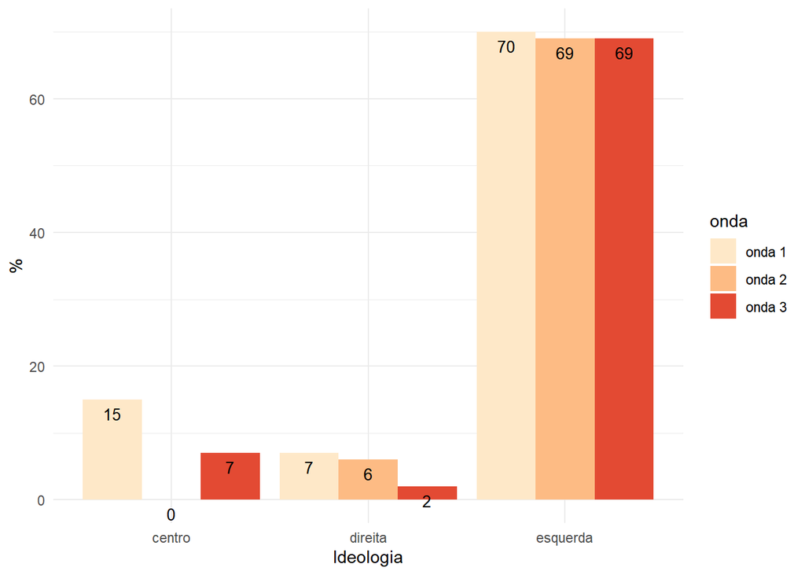

**Fonte:** Dados da pesquisa e elaboração dos autores.

**Figura 2:** Defesas ao Poder Executivo na Câmara dos Deputados por espectro e por onda nos discursos que tratam de pandemia e mencionam o Executivo

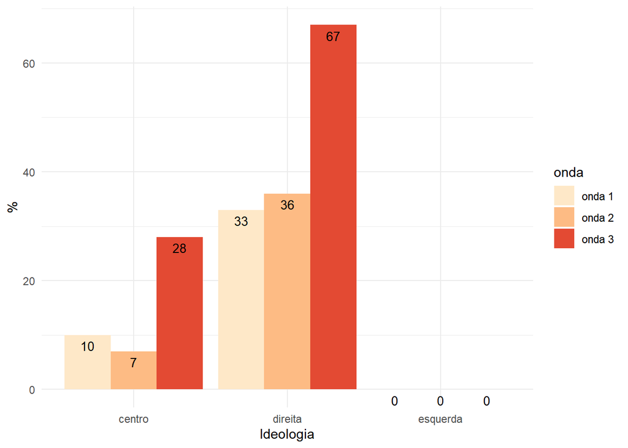

**Fonte:** Dados da pesquisa e elaboração dos autores.

**Figura 3:** Ataques ao Poder Executivo no Senado Federal por espectro e por onda nos discursos que tratam de pandemia e mencionam o Executivo

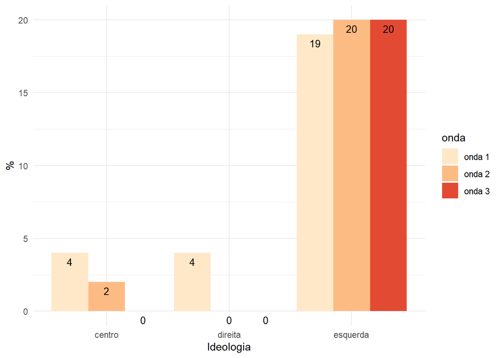

**Fonte:** Dados da pesquisa e elaboração dos autores.

**Figura 4:** Defesas ao Poder Executivo no Senado Federal por espectro e por onda nos discursos que tratam de pandemia e mencionam o Executivo

[figure not shown]

**Fonte:** Dados da pesquisa e elaboração dos autores.

**Figura 5:** Ataque de partidos com ministério na Câmara dos Deputados por espectro e por onda nos discursos que tratam de pandemia e mencionam o Executivo

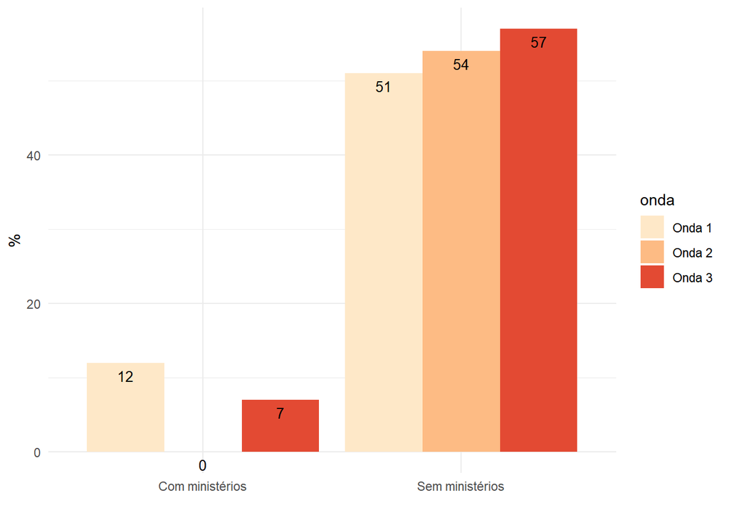

**Fonte:** Dados da pesquisa e elaboração dos autores.

**Figura 6:** Defesa de partidos com ministério na Câmara dos Deputados por espectro e por onda nos discursos que tratam de pandemia e mencionam o Executivo

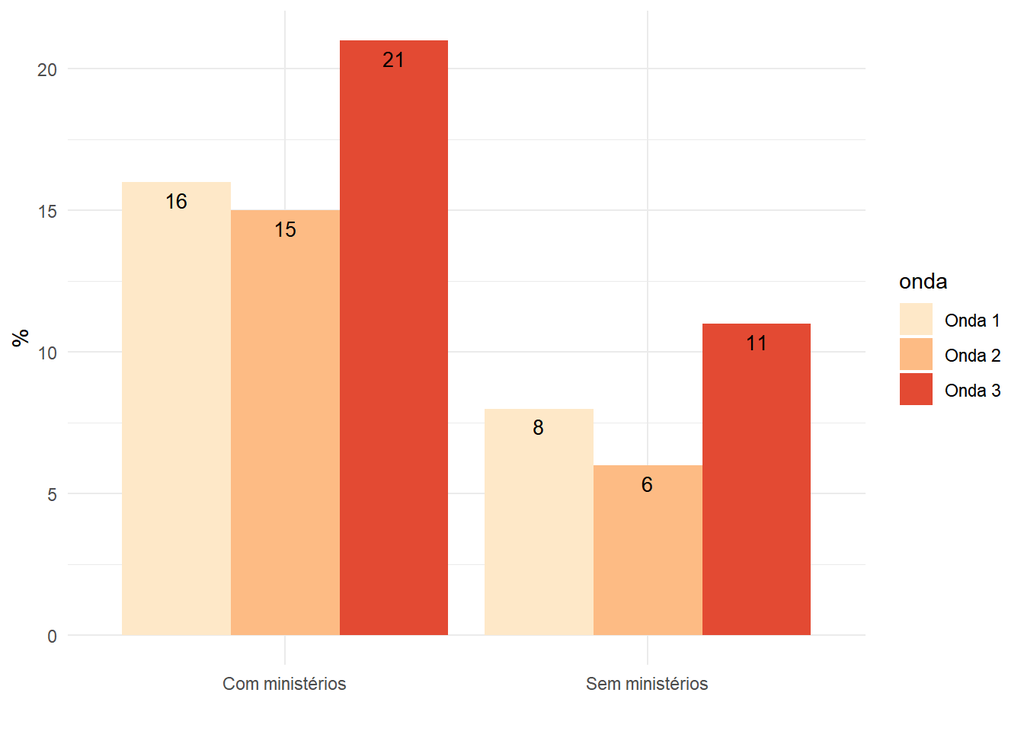

Por último, destrinchamos alguns posicionamentos temáticos dos parlamentares, a fim de ratificar se as posições acima são confirmadas pelo conteúdo substantivo das falas acerca do distanciamento social, com auxílio econômico e sobre impeachment. Fica claro que a esquerda é muito mais vocal no que tange o tema de distanciamento social nas fases iniciais da pandemia, mas perde esse papel de destaque no desenrolar da crise, compartilhando-o com o centro.

**Figura 7:** Apoio ao distanciamento social e auxílio econômico na Câmara dos Deputados por espectro e por onda

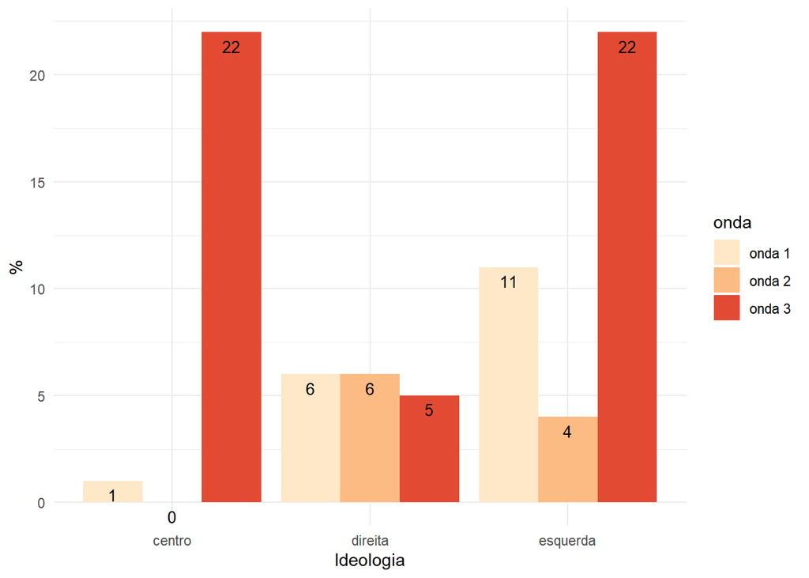

**Fonte:** Dados da pesquisa e elaboração dos autores.

# 6 Conclusão

O retorno da popularidade do Presidente não confirma o que a literatura prevê sobre o não confronto com a oposição, podendo apontar para o fato de que exista uma estratégia no sentido de coletar os benefícios do enfrentamento e afastar-se dos prejuízos gerados pela crise.

# Referências

ARNOLD, R. The logic of congressional action. New Heaven, CT: Yale University Press, 1990.

BAEKGAARD, M. et al. Rallying around the flag in times of COVID-19: Societal lockdown and trust in democratic institutions. Journal of Behavioral Public Administration, v. 3, n. 2, p. 1–28, 2020.

BAL, R. et al. Practicing Corona – Towards a research agenda of health policies. Health Policy, v. 124, n. 7, p. 671–673, 2020.

BARRIOS, J. M.; HOCHBERG, Y. V. Risk Perception Through the Lens of Politics in the Time of the COVID-19 Pandemic. SSRN Electronic Journal, 2020.

BOAS, T. C.; HIDALGO, F. D.; MELO, M. A. Norms versus Action: Why Voters Fail to Sanction Malfeasance in Brazil. American Journal of Political Science, v. 63, n. 2, p. 385–400, 2019.

BOL, D. et al. The effect of COVID-19 lockdowns on political support: Some good news for democracy? European Journal of Political Research, p. 1–9, 2020.

CAMPELLO, D.; ZUCCO, C. Presidential success and the world economy. Journal of Politics, v. 78, n. 2, p. 589–602, 2016.

CARPENTER, D. Is Health Politics Different? Annual Review of Political Science, v. 15, p. 287–311, 2012.

CEPALUNI, G.; DORSCH, M.; BRANYICZKI, R. Political Regimes and Deaths in the Early Stages of the COVID-19 Pandemic. SSRN Electronic Journal, 2020.

DESPOSATO, S. W. The impact of electoral rules on legislative parties: Lessons from the Brazilian Senate and Chamber of Deputies. Journal of Politics, v. 68, n. 4, p. 1018–1030, 2006.

FLINDERS, M. Democracy and the Politics of Coronavirus: Trust, Blame and Understanding. Parliamentary Affairs, 2020.

GREER, S. L. et al. The comparative politics of COVID-19: The need to understand government responses. Global Public Health, 2020.

HETHERINGTON, M. J.; NELSON, M. Anatomy of a Rally Effect: George W. Bush and the War on Terrorism. Political Science and Politics, v. 36, n. 01, p. 37–42, 30 jan. 2003.

HOOD, C. The Blame Game. Princeton: Princeton University Press, 2010. v. 35

JUCÁ, I.; MELO, M. A.; RENNÓ, L. The political cost of corruption: Scandals, campaign finance, and reelection in the Brazilian chamber of deputies. Journal of Politics in Latin America, 2016.

KARANIKOLOS, M.; MONITOR, M. M. How comparable is COVID-19 mortality across countries. Disponível em: https://analysis.covid19healthsystem.org/index.php/2020/06/04/how-comparable-is-covid-19-mortality-across-countries/. Acesso em: 12 set. 2020.

KAVANAGH, M. M.; SINGH, R. Democracy, Capacity, and Coercion in Pandemic Response-COVID 19 in Comparative Political Perspective. Forthcoming in an issue of Journal of Health Politics, 2020.

KEANE, J. The New Despotism. Cambridge, MA: Harvard University Press, 2020. v. 1

KLAŠNJA, M.; TITIUNIK, R. The Incumbency Curse: Weak Parties, Term Limits, and Unfulfilled Accountability. American Political Science Review, v. 111, n. 1, p. 129–148, 2017.

KRAMER, G. H. Short-Term Fluctuations in U.S. Voting Behavior, 1896–1964. American Political Science Review, v. 65, n. 1, p. 131–143, 1 mar. 1971.

MEIRELES, F. Carreiras Políticas na Câmara dos Deputados: uma análise quase-Experimental. Dados, v. 62, n. 4, p. 1–38, 2019.

MELO, M. A sobrevida dos governadores. Folha de São Paulo. 2020.

MEYER, B. Pandemic Populism: An Analysis of Populist Leaders’ Responses to Covid-19. Tony Blair Institute for Global Change, 2020.

MORONE, J. A.; JACOBS, L. R. Healthy, Wealthy, and Fair. USA: Oxford University Press, 2005.

MUELLER, J. War, presidents, and public opinion. USA: : University Press Of America, 1973.

NETO, O. A. The Presidential Calculus. Comparative Political Studies, v. 39, n. 4, p. 415–440, 2006.

NICOLAU, J. Representantes de quem?: Os (des) caminhos do seu voto da urna à Câmara dos Deputados. Rio de Janeiro: Zahar, 2017.

PAINTER, M.; QIU, T. Political Beliefs affect Compliance with COVID-19 Social Distancing Orders. SSRN Electronic Journal, 2020.

PEREIRA, C.; MEDEIROS, A.; BERTHOLINI, F. Fear of death and polarization: political consequences of the COVID-19 pandemic. Revista de Administração Pública, v. 54, n. 4, p. 952–968, ago. 2020.

PEREIRA, C.; MUELLER, B. Comportamento Estratégico em Presidencialismode Coalizão: As Relações entre Executivo e Legislativo na Elaboração do Orçamento Brasileiro. Dados, 2002.

PEREIRA, C.; MUELLER, B. Partidos fracos na arena eleitoral e partidos fortes na arena legislativa: a conexão eleitoral no Brasil. Dados, v. 46, n. 4, p. 735–771, 2003.

PÉREZ-LIÑÁN, A. Presidential impeachment and the new political instability in Latin America. USA: Cambridge University Press, 2007.

POWER, T. J.; JR, C. Z. Estimating Ideology of Brazilian Legislative Parties, 1990-2005. Latin American Research Review, v. 44, n. 1, p. 218–246, 2009.

WEAVER, K. R. The Politics of Blame Avoidance Author. Journal of Public Policy, v. 6, n. 4, p. 371–398, 1986.

ZUCCO, C.; POWER, T. Brazilian Legislative Surveys (Waves 1-8, 1990-2017). Harvard Dataverse, 2019.

#### Notas

[^1]: “Todos pela pátria”: Conceito sistematizado nos anos 70 para tratar dos efeitos sociais e políticos gerados por eventos de grande comoção nacional, como, por exemplo, guerras (MUELLER, 1973).
[^2]: A pesar de a literatura que trata do efeito rally-‘round-the-flag demonstrar aumento da popularidade presidencial em casos de crise, igualmente condiciona esse efeito a uma duração curta, circunscrita aos critérios da crise (HETHERINGTON; NELSON, 2003).
[^3]: Os discursos foram analisados de forma manual. A coleta e a análise se deram no mês de setembro de 2020. Através das buscas, os discursos foram estruturados em forma de tabela, lidos e classificados de acordo com as categorias que serão apresentadas.
[^4]: As palavras-chaves foram: “pandemia”, “covid”, “coronavírus”, “isolamento”, “lockdown” e “auxílio econômico”. O processo de limpeza de duplicatas se deu através dos códigos identificadores de cada discurso, o seu autor e a data do pronunciamento.
[^5]: Em ambas as tabelas, a classificação de “Demais assuntos” diz respeito a diferentes temáticas discutidas pelo parlamento, como, por exemplo: “segurança pública”, “educação”, “agricultura” etc. Dessa forma, o recorte mais importante é aquele dado a presença do debate sobre a pandemia, deixando discurso que não levantavam o tema fora da amostra analisada.